# Arithmetic Operators

# Adding element to a Dictionary

```python
dict2 = {'Ramish': [150,46], 'Suresh': [146,58], 'Sudesh': [160,50]}
```

```python
# Adding a sing element
dict2['Neeraj']=[176,75]
```

```python
dict2
```

```
{'Ramish': [150, 46],
 'Suresh': [146, 58],
 'Sudesh': [160, 50],
 'Neeraj': [176, 75]}
```

```python
# Adding multiple element at once
dict2.update({'sunil': [150,70], 'disha': [155,80]})
```

```python
dict2
```

```
{'Ramish': [150, 46],
 'Suresh': [146, 58],
 'Sudesh': [160, 50],
 'Neeraj': [176, 75],
 'sunil': [150, 70],
 'disha': [155, 80]}
```

# Deleting element of a Dictionary

```python
dict2 = {'Ramish': [150,46], 'Suresh': [146,58], 'Sudesh': [160,50]}
```

```python
# Deleting an element
del dict2['Ramish']
```

```python
dict2
```

```
{'Suresh': [146, 58], 'Sudesh': [160, 50]}
```

# Implementation

```python
# Creating a dictionary
marks = {'History': 45, 'Geography': 54, 'Hindi': 56}
```

```python
marks
```

```
{'History': 45, 'Geography': 54, 'Hindi': 56}
```

```python
# Access elements
marks['Geography']
```

```
54
```

```python
# Adding elements
marks['English'] = 47
```

```python
marks
```

```
{'History': 45, 'Geography': 54, 'Hindi': 56, 'English': 47}
```

```python
# Adding multiple elements
marks.update({'Chemistry': 89, 'Physics': 98})
```

```python
marks
```

```
{'History': 45,
 'Geography': 54,
 'Hindi': 56,
 'English': 47,
 'Chemistry': 89,
 'Physics': 98}
```

```python
# Deleting elements
del marks['Hindi']
```

```python
marks
```

```
{'History': 45, 'Geography': 54, 'English': 47, 'Chemistry': 89, 'Physics': 98}
```

# Understanding the concept of Standard Libraries

# PANDAS

```python
# importing pandas library

import pandas as pd
```

```python
# reading the csv file

df = pd.read_csv('data.csv')
```

```python
df.head()
```

|  | PassengerId | Survived | Pclass | Name | Sex | Age | SibSp | Parch | Ticket | Fare | Cabin | Embarked |
| --- | --- | --- | --- | --- | --- | --- | --- | --- | --- | --- | --- | --- |
| 0 | 1 | 0 | 3 | Braund, Mr. Owen Harris | male | 22.0 | 1 | 0 | A/5 21171 | 7.2500 | NaN | S |
| 1 | 2 | 1 | 1 | Cumings, Mrs. John Bradley (Florence Briggs Th... | female | 38.0 | 1 | 0 | PC 17599 | 71.2833 | C85 | C |
| 2 | 3 | 1 | 3 | Heikkinen, Miss. Laina | female | 26.0 | 0 | 0 | STON/O2. 3101282 | 7.9250 | NaN | S |
| 3 | 4 | 1 | 1 | Futrelle, Mrs. Jacques Heath (Lily May Peel) | female | 35.0 | 1 | 0 | 113803 | 53.1000 | C123 | S |
| 4 | 5 | 0 | 3 | Allen, Mr. William Henry | male | 35.0 | 0 | 0 | 373450 | 8.0500 | NaN | S |

```python
pwd
```

```
'C:\\Users\\dashd'
```

```python
cd C:\Users\dashd\Desktop\Python for Data Science
```

```
C:\Users\dashd\Desktop\Python for Data Science
```

```python
df = pd.read_csv('data.csv')
```

```python
df.head()
```

|  | PassengerId | Survived | Pclass | Name | Sex | Age | SibSp | Parch | Ticket | Fare | Cabin | Embarked |
| --- | --- | --- | --- | --- | --- | --- | --- | --- | --- | --- | --- | --- |
| 0 | 1 | 0 | 3 | Braund, Mr. Owen Harris | male | 22.0 | 1 | 0 | A/5 21171 | 7.2500 | NaN | S |
| 1 | 2 | 1 | 1 | Cumings, Mrs. John Bradley (Florence Briggs Th... | female | 38.0 | 1 | 0 | PC 17599 | 71.2833 | C85 | C |
| 2 | 3 | 1 | 3 | Heikkinen, Miss. Laina | female | 26.0 | 0 | 0 | STON/O2. 3101282 | 7.9250 | NaN | S |
| 3 | 4 | 1 | 1 | Futrelle, Mrs. Jacques Heath (Lily May Peel) | female | 35.0 | 1 | 0 | 113803 | 53.1000 | C123 | S |
| 4 | 5 | 0 | 3 | Allen, Mr. William Henry | male | 35.0 | 0 | 0 | 373450 | 8.0500 | NaN | S |

```python
# reading excel file

df1 = pd.read_excel('data.xlsx')
```

```python
df1.head()
```

|  | PassengerId | Survived | Pclass | Name | Sex | Age | SibSp | Parch | Ticket | Fare | Cabin | Embarked |
| --- | --- | --- | --- | --- | --- | --- | --- | --- | --- | --- | --- | --- |
| 0 | 1 | 0 | 3 | Braund, Mr. Owen Harris | male | 22.0 | 1 | 0 | A/5 21171 | 7.2500 | NaN | S |
| 1 | 2 | 1 | 1 | Cumings, Mrs. John Bradley (Florence Briggs Th... | female | 38.0 | 1 | 0 | PC 17599 | 71.2833 | C85 | C |
| 2 | 3 | 1 | 3 | Heikkinen, Miss. Laina | female | 26.0 | 0 | 0 | STON/O2. 3101282 | 7.9250 | NaN | S |
| 3 | 4 | 1 | 1 | Futrelle, Mrs. Jacques Heath (Lily May Peel) | female | 35.0 | 1 | 0 | 113803 | 53.1000 | C123 | S |
| 4 | 5 | 0 | 3 | Allen, Mr. William Henry | male | 35.0 | 0 | 0 | 373450 | 8.0500 | NaN | S |

```python
df.shape[0]
```

```
891
```

```python
df.shape[1]
```

```
12
```

# Dataframe and Basic operations

```python
# seeing the dimensions of the dataframe

df.shape
```

```
(891, 12)
```

```python
df.head()
```

|  | PassengerId | Survived | Pclass | Name | Sex | Age | SibSp | Parch | Ticket | Fare | Cabin | Embarked |
| --- | --- | --- | --- | --- | --- | --- | --- | --- | --- | --- | --- | --- |
| 0 | 1 | 0 | 3 | Braund, Mr. Owen Harris | male | 22.0 | 1 | 0 | A/5 21171 | 7.2500 | NaN | S |
| 1 | 2 | 1 | 1 | Cumings, Mrs. John Bradley (Florence Briggs Th... | female | 38.0 | 1 | 0 | PC 17599 | 71.2833 | C85 | C |
| 2 | 3 | 1 | 3 | Heikkinen, Miss. Laina | female | 26.0 | 0 | 0 | STON/O2. 3101282 | 7.9250 | NaN | S |
| 3 | 4 | 1 | 1 | Futrelle, Mrs. Jacques Heath (Lily May Peel) | female | 35.0 | 1 | 0 | 113803 | 53.1000 | C123 | S |
| 4 | 5 | 0 | 3 | Allen, Mr. William Henry | male | 35.0 | 0 | 0 | 373450 | 8.0500 | NaN | S |

```python
df.tail()
```

|  | PassengerId | Survived | Pclass | Name | Sex | Age | SibSp | Parch | Ticket | Fare | Cabin | Embarked |
| --- | --- | --- | --- | --- | --- | --- | --- | --- | --- | --- | --- | --- |
| 886 | 887 | 0 | 2 | Montvila, Rev. Juozas | male | 27.0 | 0 | 0 | 211536 | 13.00 | NaN | S |
| 887 | 888 | 1 | 1 | Graham, Miss. Margaret Edith | female | 19.0 | 0 | 0 | 112053 | 30.00 | B42 | S |
| 888 | 889 | 0 | 3 | Johnston, Miss. Catherine Helen "Carrie" | female | NaN | 1 | 2 | W./C. 6607 | 23.45 | NaN | S |
| 889 | 890 | 1 | 1 | Behr, Mr. Karl Howell | male | 26.0 | 0 | 0 | 111369 | 30.00 | C148 | C |
| 890 | 891 | 0 | 3 | Dooley, Mr. Patrick | male | 32.0 | 0 | 0 | 370376 | 7.75 | NaN | Q |

```python
# seeing the names of columns in dataframe

df.columns
```

```
Index(['PassengerId', 'Survived', 'Pclass', 'Name', 'Sex', 'Age', 'SibSp',
       'Parch', 'Ticket', 'Fare', 'Cabin', 'Embarked'],
      dtype='object')
```

```python
# selecting a single column

df['Name']
```

```
0                                Braund, Mr. Owen Harris
1      Cumings, Mrs. John Bradley (Florence Briggs Th...
2                                 Heikkinen, Miss. Laina
3           Futrelle, Mrs. Jacques Heath (Lily May Peel)
4                               Allen, Mr. William Henry
                             ...
886                                Montvila, Rev. Juozas
887                         Graham, Miss. Margaret Edith
888             Johnston, Miss. Catherine Helen "Carrie"
889                                Behr, Mr. Karl Howell
890                                  Dooley, Mr. Patrick
Name: Name, Length: 891, dtype: object
```

```python
# selecting multiple columns using names

df[['Name', 'Age']]
```

|  | Name | Age |
| --- | --- | --- |
| 0 | Braund, Mr. Owen Harris | 22.0 |
| 1 | Cumings, Mrs. John Bradley (Florence Briggs Th... | 38.0 |
| 2 | Heikkinen, Miss. Laina | 26.0 |
| 3 | Futrelle, Mrs. Jacques Heath (Lily May Peel) | 35.0 |
| 4 | Allen, Mr. William Henry | 35.0 |
| ... | ... | ... |
| 886 | Montvila, Rev. Juozas | 27.0 |
| 887 | Graham, Miss. Margaret Edith | 19.0 |
| 888 | Johnston, Miss. Catherine Helen "Carrie" | NaN |
| 889 | Behr, Mr. Karl Howell | 26.0 |
| 890 | Dooley, Mr. Patrick | 32.0 |

891 rows × 2 columns

```python
import pandas as pd
```

```python
df = pd.read_csv('./data.csv')
```

```python
df.head()
```

|  | PassengerId | Survived | Pclass | Name | Sex | Age | SibSp | Parch | Ticket | Fare | Cabin | Embarked |
| --- | --- | --- | --- | --- | --- | --- | --- | --- | --- | --- | --- | --- |
| 0 | 1 | 0 | 3 | Braund, Mr. Owen Harris | male | 22.0 | 1 | 0 | A/5 21171 | 7.2500 | NaN | S |
| 1 | 2 | 1 | 1 | Cumings, Mrs. John Bradley (Florence Briggs Th... | female | 38.0 | 1 | 0 | PC 17599 | 71.2833 | C85 | C |
| 2 | 3 | 1 | 3 | Heikkinen, Miss. Laina | female | 26.0 | 0 | 0 | STON/O2. 3101282 | 7.9250 | NaN | S |
| 3 | 4 | 1 | 1 | Futrelle, Mrs. Jacques Heath (Lily May Peel) | female | 35.0 | 1 | 0 | 113803 | 53.1000 | C123 | S |
| 4 | 5 | 0 | 3 | Allen, Mr. William Henry | male | 35.0 | 0 | 0 | 373450 | 8.0500 | NaN | S |

```python
import pandas as pd
```

```python
cd C:\Users\dashd\Desktop\Python for Data Science
```

```
C:\Users\dashd\Desktop\Python for Data Science
```

```python
df1 = pd.read_csv('data1.csv')
```

```python
df1.head()
```

|  | ID | Clump_Thickness | Cell_Size_Uniformity | Cell_Shape_Uniformity | Marginal_Adhesion | Single_Epithelial_Cell_Size | Bare_Nuclei | Bland_Chromatin | Normal_Nucleoli | Mitoses | Cancer_Type |
| --- | --- | --- | --- | --- | --- | --- | --- | --- | --- | --- | --- |
| 0 | 1000025 | 5 | 1 | 1 | 1 | 2.0 | 1 | 3 | 1 | 1 | 2 |
| 1 | 1002945 | 5 | 4 | 4 | 5 | NaN | 10 | 3 | 2 | 1 | 2 |
| 2 | 1015425 | 3 | 1 | 1 | 1 | 2.0 | 2 | 3 | 1 | 1 | 2 |
| 3 | 1016277 | 6 | 8 | 8 | 1 | 3.0 | 4 | 3 | 7 | 1 | 2 |
| 4 | 1017023 | 4 | 1 | 1 | 3 | 2.0 | 1 | 3 | 1 | 1 | 2 |

```python
# selecting a single column by name

df1['Bare_Nuclei']
```

```
0       1
1      10
2       2
3       4
4       1
       ..
694     2
695     1
696     3
697     4
698     5
Name: Bare_Nuclei, Length: 699, dtype: object
```

```python
# selecting multiple columns using column names

df1[['Clump_Thickness', 'Marginal_Adhesion']]
```

|  | Clump_Thickness | Marginal_Adhesion |
| --- | --- | --- |
| 0 | 5 | 1 |
| 1 | 5 | 5 |
| 2 | 3 | 1 |
| 3 | 6 | 1 |
| 4 | 4 | 3 |
| ... | ... | ... |
| 694 | 3 | 1 |
| 695 | 2 | 1 |
| 696 | 5 | 3 |
| 697 | 4 | 4 |
| 698 | 4 | 5 |

699 rows × 2 columns

```python
# selecting rows by their positions

df1.iloc[:5]
```

|  | ID | Clump_Thickness | Cell_Size_Uniformity | Cell_Shape_Uniformity | Marginal_Adhesion | Single_Epithelial_Cell_Size | Bare_Nuclei | Bland_Chromatin | Normal_Nucleoli | Mitoses | Cancer_Type |
| --- | --- | --- | --- | --- | --- | --- | --- | --- | --- | --- | --- |
| 0 | 1000025 | 5 | 1 | 1 | 1 | 2.0 | 1 | 3 | 1 | 1 | 2 |
| 1 | 1002945 | 5 | 4 | 4 | 5 | NaN | 10 | 3 | 2 | 1 | 2 |
| 2 | 1015425 | 3 | 1 | 1 | 1 | 2.0 | 2 | 3 | 1 | 1 | 2 |
| 3 | 1016277 | 6 | 8 | 8 | 1 | 3.0 | 4 | 3 | 7 | 1 | 2 |
| 4 | 1017023 | 4 | 1 | 1 | 3 | 2.0 | 1 | 3 | 1 | 1 | 2 |

```python
# selecting columns by their position

df1.iloc[:,:2]
```

|  | ID | Clump_Thickness |
| --- | --- | --- |
| 0 | 1000025 | 5 |
| 1 | 1002945 | 5 |
| 2 | 1015425 | 3 |
| 3 | 1016277 | 6 |
| 4 | 1017023 | 4 |
| ... | ... | ... |
| 694 | 776715 | 3 |
| 695 | 841769 | 2 |
| 696 | 888820 | 5 |
| 697 | 897471 | 4 |
| 698 | 897471 | 4 |

699 rows × 2 columns

```python
# selecting columns for specific condition

df1[df1['Cancer_Type']==4]
```

|  | ID | Clump_Thickness | Cell_Size_Uniformity | Cell_Shape_Uniformity | Marginal_Adhesion | Single_Epithelial_Cell_Size | Bare_Nuclei | Bland_Chromatin | Normal_Nucleoli | Mitoses | Cancer_Type |
| --- | --- | --- | --- | --- | --- | --- | --- | --- | --- | --- | --- |
| 5 | 1017122 | 8 | 10 | 10 | 8 | 7.0 | 10 | 9 | 7 | 1 | 4 |
| 12 | 1041801 | 5 | 3 | 3 | 3 | 2.0 | 3 | 4 | 4 | 1 | 4 |
| 14 | 1044572 | 8 | 7 | 5 | 10 | 7.0 | 9 | 5 | 5 | 4 | 4 |
| 15 | 1047630 | 7 | 4 | 6 | 4 | 6.0 | 1 | 4 | 3 | 1 | 4 |
| 18 | 1050670 | 10 | 7 | 7 | 6 | 4.0 | 10 | 4 | 1 | 2 | 4 |
| ... | ... | ... | ... | ... | ... | ... | ... | ... | ... | ... | ... |
| 681 | 1371026 | 5 | 10 | 10 | 10 | 4.0 | 10 | 5 | 6 | 3 | 4 |
| 691 | 695091 | 5 | 10 | 10 | 5 | 4.0 | 5 | 4 | 4 | 1 | 4 |
| 696 | 888820 | 5 | 10 | 10 | 3 | 7.0 | 3 | 8 | 10 | 2 | 4 |
| 697 | 897471 | 4 | 8 | 6 | 4 | 3.0 | 4 | 10 | 6 | 1 | 4 |
| 698 | 897471 | 4 | 8 | 8 | 5 | 4.0 | 5 | 10 | 4 | 1 | 4 |

241 rows × 11 columns

```python
df2 = pd.read_csv('./index.csv')
```

```python
df2.head()
```

|  | A | B | C | D | E | F | G | H | I | J | K | L |
| --- | --- | --- | --- | --- | --- | --- | --- | --- | --- | --- | --- | --- |
| 0 | C | A | 8 | 0 | S | 0 | COIL | 0.700 | 610.0 | 0 | 0 | 3 |
| 1 | C | R | 0 | 0 | S | 0 | COIL | 3.200 | 610.0 | 0 | 0 | 3 |
| 2 | C | R | 0 | 0 | S | 0 | SHEET | 0.700 | 1300.0 | 762 | 0 | 3 |
| 3 | C | A | 0 | 60 | ? | 0 | COIL | 2.801 | 385.1 | 0 | 0 | 3 |
| 4 | C | A | 0 | 60 | ? | 0 | SHEET | 0.801 | 255.0 | 269 | 0 | 3 |

```python
# Accessing the third column
df2['C']
```

```
0       8
1       0
2       0
3       0
4       0
       ..
252     0
253     6
254     0
255    45
256     6
Name: C, Length: 257, dtype: int64
```

```python
# Accessing the last two columns of df2 using iloc function

df2.iloc[:,[-2,-1]]
```

|  | K | L |
| --- | --- | --- |
| 0 | 0 | 3 |
| 1 | 0 | 3 |
| 2 | 0 | 3 |
| 3 | 0 | 3 |
| 4 | 0 | 3 |
| ... | ... | ... |
| 252 | 0 | 3 |
| 253 | 0 | 3 |
| 254 | 0 | 3 |
| 255 | 0 | 3 |
| 256 | 0 | 3 |

257 rows × 2 columns

```python
# Accessing the last 10 rows and the first two columns of df2

df2.iloc[-10:, :2]
```

|  | A | B |
| --- | --- | --- |
| 247 | C | R |
| 248 | C | A |
| 249 | C | A |
| 250 | C | R |
| 251 | C | A |
| 252 | C | A |
| 253 | C | R |
| 254 | C | A |
| 255 | C | K |
| 256 | C | R |

# Data Manipulation and Data Exploration for Visualization

# Data Manipulation using Pandas Library

```python
import pandas as pd
import numpy as np
```

```python
# reading the dataset

data_BM = pd.read_csv('bigmart_data.csv')
```

```python
data_BM.head()
```

|  | Item_Identifier | Item_Weight | Item_Fat_Content | Item_Visibility | Item_Type | Item_MRP | Outlet_Identifier | Outlet_Establishment_Year | Outlet_Size | Outlet_Location_Type | Outlet_Type | Item_Outlet_Sales |
| --- | --- | --- | --- | --- | --- | --- | --- | --- | --- | --- | --- | --- |
| 0 | FDA15 | 9.30 | Low Fat | 0.016047 | Dairy | 249.8092 | OUT049 | 1999 | Medium | Tier 1 | Supermarket Type1 | 3735.1380 |
| 1 | DRC01 | 5.92 | Regular | 0.019278 | Soft Drinks | 48.2692 | OUT018 | 2009 | Medium | Tier 3 | Supermarket Type2 | 443.4228 |
| 2 | FDN15 | 17.50 | Low Fat | 0.016760 | Meat | 141.6180 | OUT049 | 1999 | Medium | Tier 1 | Supermarket Type1 | 2097.2700 |
| 3 | FDX07 | 19.20 | Regular | 0.000000 | Fruits and Vegetables | 182.0950 | OUT010 | 1998 | NaN | Tier 3 | Grocery Store | 732.3800 |
| 4 | NCD19 | 8.93 | Low Fat | 0.000000 | Household | 53.8614 | OUT013 | 1987 | High | Tier 3 | Supermarket Type1 | 994.7052 |

```python
# drop the null values

data_BM = data_BM.dropna(how = 'any')
```

```python
data_BM.head()
```

|  | Item_Identifier | Item_Weight | Item_Fat_Content | Item_Visibility | Item_Type | Item_MRP | Outlet_Identifier | Outlet_Establishment_Year | Outlet_Size | Outlet_Location_Type | Outlet_Type | Item_Outlet_Sales |
| --- | --- | --- | --- | --- | --- | --- | --- | --- | --- | --- | --- | --- |
| 0 | FDA15 | 9.300 | Low Fat | 0.016047 | Dairy | 249.8092 | OUT049 | 1999 | Medium | Tier 1 | Supermarket Type1 | 3735.1380 |
| 1 | DRC01 | 5.920 | Regular | 0.019278 | Soft Drinks | 48.2692 | OUT018 | 2009 | Medium | Tier 3 | Supermarket Type2 | 443.4228 |
| 2 | FDN15 | 17.500 | Low Fat | 0.016760 | Meat | 141.6180 | OUT049 | 1999 | Medium | Tier 1 | Supermarket Type1 | 2097.2700 |
| 4 | NCD19 | 8.930 | Low Fat | 0.000000 | Household | 53.8614 | OUT013 | 1987 | High | Tier 3 | Supermarket Type1 | 994.7052 |
| 5 | FDP36 | 10.395 | Regular | 0.000000 | Baking Goods | 51.4008 | OUT018 | 2009 | Medium | Tier 3 | Supermarket Type2 | 556.6088 |

# Sorting dataframe

```python
# sort by year
sorted_data = data_BM.sort_values(by = "Outlet_Establishment_Year")
# print sorted data
sorted_data[:5]
```

|  | Item_Identifier | Item_Weight | Item_Fat_Content | Item_Visibility | Item_Type | Item_MRP | Outlet_Identifier | Outlet_Establishment_Year | Outlet_Size | Outlet_Location_Type | Outlet_Type | Item_Outlet_Sales |
| --- | --- | --- | --- | --- | --- | --- | --- | --- | --- | --- | --- | --- |
| 2812 | FDR60 | 14.30 | Low Fat | 0.130307 | Baking Goods | 75.7328 | OUT013 | 1987 | High | Tier 3 | Supermarket Type1 | 617.8624 |
| 5938 | NCJ06 | 20.10 | Low Fat | 0.034624 | Household | 118.9782 | OUT013 | 1987 | High | Tier 3 | Supermarket Type1 | 1549.3166 |
| 3867 | FDY38 | 13.60 | Regular | 0.119077 | Dairy | 231.2300 | OUT013 | 1987 | High | Tier 3 | Supermarket Type1 | 2330.3000 |
| 1307 | FDB37 | 20.25 | Regular | 0.022922 | Baking Goods | 240.7538 | OUT013 | 1987 | High | Tier 3 | Supermarket Type1 | 3364.9532 |
| 5930 | NCA18 | 10.10 | Low Fat | 0.056031 | Household | 115.1492 | OUT013 | 1987 | High | Tier 3 | Supermarket Type1 | 1737.7380 |

```python
# sort in place and descending order
data_BM.sort_values(by =['Item_Outlet_Sales','Outlet_Establishment_Year'], ascending = False, inplace = True)
data_BM[:5]
```

|  | Item_Identifier | Item_Weight | Item_Fat_Content | Item_Visibility | Item_Type | Item_MRP | Outlet_Identifier | Outlet_Establishment_Year | Outlet_Size | Outlet_Location_Type | Outlet_Type | Item_Outlet_Sales |
| --- | --- | --- | --- | --- | --- | --- | --- | --- | --- | --- | --- | --- |
| 4888 | FDF39 | 14.850 | Regular | 0.019495 | Dairy | 261.2910 | OUT013 | 1987 | High | Tier 3 | Supermarket Type1 | 10256.6490 |
| 4289 | NCM05 | 6.825 | Low Fat | 0.059847 | Health and Hygiene | 262.5226 | OUT046 | 1997 | Small | Tier 1 | Supermarket Type1 | 9779.9362 |
| 6409 | FDA21 | 13.650 | Low Fat | 0.035931 | Snack Foods | 184.4924 | OUT013 | 1987 | High | Tier 3 | Supermarket Type1 | 9069.5276 |
| 4991 | NCQ53 | 17.600 | Low Fat | 0.018905 | Health and Hygiene | 234.6590 | OUT046 | 1997 | Small | Tier 1 | Supermarket Type1 | 8508.9240 |
| 5752 | FDI15 | 13.800 | Low Fat | 0.141326 | Dairy | 265.0884 | OUT035 | 2004 | Small | Tier 2 | Supermarket Type1 | 8479.6288 |

```python
# sort by index
data_BM.sort_index(inplace = True)
data_BM[:5]
```

|  | Item_Identifier | Item_Weight | Item_Fat_Content | Item_Visibility | Item_Type | Item_MRP | Outlet_Identifier | Outlet_Establishment_Year | Outlet_Size | Outlet_Location_Type | Outlet_Type | Item_Outlet_Sales |
| --- | --- | --- | --- | --- | --- | --- | --- | --- | --- | --- | --- | --- |
| 0 | FDA15 | 9.300 | Low Fat | 0.016047 | Dairy | 249.8092 | OUT049 | 1999 | Medium | Tier 1 | Supermarket Type1 | 3735.1380 |
| 1 | DRC01 | 5.920 | Regular | 0.019278 | Soft Drinks | 48.2692 | OUT018 | 2009 | Medium | Tier 3 | Supermarket Type2 | 443.4228 |
| 2 | FDN15 | 17.500 | Low Fat | 0.016760 | Meat | 141.6180 | OUT049 | 1999 | Medium | Tier 1 | Supermarket Type1 | 2097.2700 |
| 4 | NCD19 | 8.930 | Low Fat | 0.000000 | Household | 53.8614 | OUT013 | 1987 | High | Tier 3 | Supermarket Type1 | 994.7052 |
| 5 | FDP36 | 10.395 | Regular | 0.000000 | Baking Goods | 51.4008 | OUT018 | 2009 | Medium | Tier 3 | Supermarket Type2 | 556.6088 |

# Merge dataframes using Pandas

```python
# craete dummy data
df1 = pd.DataFrame({'A': ['A0', 'A1', 'A2', 'A3'],
                    'B': ['B0', 'B1', 'B2', 'B3'],
                    'C': ['C0', 'C1', 'C2', 'C3'],
                    'D': ['D0', 'D1', 'D2', 'D3']},
                  index = [0, 1, 2,3])

df2 = pd.DataFrame({'A': ['A4', 'A5', 'A6', 'A7'],
                    'B': ['B4', 'B5', 'B6', 'B7'],
                    'C': ['C4', 'C5', 'C6', 'C7'],
                    'D': ['D4', 'D5', 'D6', 'D7']},
                  index = [4, 5, 6,7])

df3 = pd.DataFrame({'A': ['A8', 'A9', 'A10', 'A11'],
                    'B': ['B8', 'B9', 'B10', 'B11'],
                    'C': ['C8', 'C9', 'C10', 'C11'],
                    'D': ['D8', 'D9', 'D10', 'D11']},
                  index = [8, 9, 10,11])
```

```python
df1
```

|  | A | B | C | D |
| --- | --- | --- | --- | --- |
| 0 | A0 | B0 | C0 | D0 |
| 1 | A1 | B1 | C1 | D1 |
| 2 | A2 | B2 | C2 | D2 |
| 3 | A3 | B3 | C3 | D3 |

```python
df2
```

|  | A | B | C | D |
| --- | --- | --- | --- | --- |
| 4 | A4 | B4 | C4 | D4 |
| 5 | A5 | B5 | C5 | D5 |
| 6 | A6 | B6 | C6 | D6 |
| 7 | A7 | B7 | C7 | D7 |

```python
df3
```

|  | A | B | C | D |
| --- | --- | --- | --- | --- |
| 8 | A8 | B8 | C8 | D8 |
| 9 | A9 | B9 | C9 | D9 |
| 10 | A10 | B10 | C10 | D10 |
| 11 | A11 | B11 | C11 | D11 |

```python
# combine dataframe
result = pd.concat([df1, df2, df3])
result
```

|  | A | B | C | D |
| --- | --- | --- | --- | --- |
| 0 | A0 | B0 | C0 | D0 |
| 1 | A1 | B1 | C1 | D1 |
| 2 | A2 | B2 | C2 | D2 |
| 3 | A3 | B3 | C3 | D3 |
| 4 | A4 | B4 | C4 | D4 |
| 5 | A5 | B5 | C5 | D5 |
| 6 | A6 | B6 | C6 | D6 |
| 7 | A7 | B7 | C7 | D7 |
| 8 | A8 | B8 | C8 | D8 |
| 9 | A9 | B9 | C9 | D9 |
| 10 | A10 | B10 | C10 | D10 |
| 11 | A11 | B11 | C11 | D11 |

```python
# combine dataframe
result = pd.concat([df1, df2, df3], keys = ['x', 'y', 'z'])
result
```

|  |  | A | B | C | D |
| --- | --- | --- | --- | --- | --- |
| x | 0 | A0 | B0 | C0 | D0 |
|  | 1 | A1 | B1 | C1 | D1 |
|  | 2 | A2 | B2 | C2 | D2 |
|  | 3 | A3 | B3 | C3 | D3 |
| y | 4 | A4 | B4 | C4 | D4 |
|  | 5 | A5 | B5 | C5 | D5 |
|  | 6 | A6 | B6 | C6 | D6 |
|  | 7 | A7 | B7 | C7 | D7 |
| z | 8 | A8 | B8 | C8 | D8 |
|  | 9 | A9 | B9 | C9 | D9 |
|  | 10 | A10 | B10 | C10 | D10 |
|  | 11 | A11 | B11 | C11 | D11 |

```python
# get second dataframe
result.loc['y']
```

|  | A | B | C | D |
| --- | --- | --- | --- | --- |
| 4 | A4 | B4 | C4 | D4 |
| 5 | A5 | B5 | C5 | D5 |
| 6 | A6 | B6 | C6 | D6 |
| 7 | A7 | B7 | C7 | D7 |

```python
# create a dummy df4 dataframe
df4 = pd.DataFrame({'B': ['B2', 'B3', 'B6', 'B7'],
                    'D': ['D2', 'D3', 'D6', 'D7'],
                    'F': ['F2', 'F3', 'F6', 'F7']},
                  index = [2, 3, 6, 7])

# use the join = "outer" (default)
result = pd.concat([df1, df4], axis = 1, sort = False)
result
```

|  | A | B | C | D | B | D | F |
| --- | --- | --- | --- | --- | --- | --- | --- |
| 0 | A0 | B0 | C0 | D0 | NaN | NaN | NaN |
| 1 | A1 | B1 | C1 | D1 | NaN | NaN | NaN |
| 2 | A2 | B2 | C2 | D2 | B2 | D2 | F2 |
| 3 | A3 | B3 | C3 | D3 | B3 | D3 | F3 |
| 6 | NaN | NaN | NaN | NaN | B6 | D6 | F6 |
| 7 | NaN | NaN | NaN | NaN | B7 | D7 | F7 |

```python
# join = "inner"
result = pd.concat([df1, df4], axis = 1, join = 'inner')
result
```

|  | A | B | C | D | B | D | F |
| --- | --- | --- | --- | --- | --- | --- | --- |
| 2 | A2 | B2 | C2 | D2 | B2 | D2 | F2 |
| 3 | A3 | B3 | C3 | D3 | B3 | D3 | F3 |

```python
# create dummy data
df_a = pd.DataFrame({
        'subject_id': ['1', '2', '3', '4', '5'],
        'first_name': ['Alex', 'Amy', 'Allen', 'Alice', 'Ayoung'],
        'last_name': ['Anderson', 'Ackerman', 'Ali', 'Aoni', 'Atiches']})

df_b = pd.DataFrame({
        'subject_id': ['4', '5', '6', '7', '8'],
        'first_name': ['Billy', 'Brian', 'Bran', 'Bryce', 'Betty'],
        'last_name': ['Bonder', 'Black', 'Balwner', 'Brice', 'Btisan']})

df_c = pd.DataFrame({
        'subject_id': ['1', '2', '3', '4', '5', '7', '8', '9', '10', '11'],
        'test_id': [51, 15, 15, 61, 16, 14, 15, 1, 61, 16]})
```

```python
df_a
```

|  | subject_id | first_name | last_name |
| --- | --- | --- | --- |
| 0 | 1 | Alex | Anderson |
| 1 | 2 | Amy | Ackerman |
| 2 | 3 | Allen | Ali |
| 3 | 4 | Alice | Aoni |
| 4 | 5 | Ayoung | Atiches |

```python
df_b
```

|  | subject_id | first_name | last_name |
| --- | --- | --- | --- |
| 0 | 4 | Billy | Bonder |
| 1 | 5 | Brian | Black |
| 2 | 6 | Bran | Balwner |
| 3 | 7 | Bryce | Brice |
| 4 | 8 | Betty | Btisan |

```python
df_c
```

|  | subject_id | test_id |
| --- | --- | --- |
| 0 | 1 | 51 |
| 1 | 2 | 15 |
| 2 | 3 | 15 |
| 3 | 4 | 61 |
| 4 | 5 | 16 |
| 5 | 7 | 14 |
| 6 | 8 | 15 |
| 7 | 9 | 1 |
| 8 | 10 | 61 |
| 9 | 11 | 16 |

```python
# basic join, combine df_a with df_c based on the subject_id column
pd.merge(df_a, df_c, on = 'subject_id')
```

|  | subject_id | first_name | last_name | test_id |
| --- | --- | --- | --- | --- |
| 0 | 1 | Alex | Anderson | 51 |
| 1 | 2 | Amy | Ackerman | 15 |
| 2 | 3 | Allen | Ali | 15 |
| 3 | 4 | Alice | Aoni | 61 |
| 4 | 5 | Ayoung | Atiches | 16 |

```python
#join = "outer"
pd.merge(df_a, df_b, on = 'subject_id', how = 'outer')
```

|  | subject_id | first_name_x | last_name_x | first_name_y | last_name_y |
| --- | --- | --- | --- | --- | --- |
| 0 | 1 | Alex | Anderson | NaN | NaN |
| 1 | 2 | Amy | Ackerman | NaN | NaN |
| 2 | 3 | Allen | Ali | NaN | NaN |
| 3 | 4 | Alice | Aoni | Billy | Bonder |
| 4 | 5 | Ayoung | Atiches | Brian | Black |
| 5 | 6 | NaN | NaN | Bran | Balwner |
| 6 | 7 | NaN | NaN | Bryce | Brice |
| 7 | 8 | NaN | NaN | Betty | Btisan |

```python
# join = inner
pd.merge(df_a, df_b, on = 'subject_id', how = 'inner')
```

|  | subject_id | first_name_x | last_name_x | first_name_y | last_name_y |
| --- | --- | --- | --- | --- | --- |
| 0 | 4 | Alice | Aoni | Billy | Bonder |
| 1 | 5 | Ayoung | Atiches | Brian | Black |

```python
# join = right
pd.merge(df_a, df_b, on = 'subject_id', how = 'right')
```

|  | subject_id | first_name_x | last_name_x | first_name_y | last_name_y |
| --- | --- | --- | --- | --- | --- |
| 0 | 4 | Alice | Aoni | Billy | Bonder |
| 1 | 5 | Ayoung | Atiches | Brian | Black |
| 2 | 6 | NaN | NaN | Bran | Balwner |
| 3 | 7 | NaN | NaN | Bryce | Brice |
| 4 | 8 | NaN | NaN | Betty | Btisan |

```python
# join = left
pd.merge(df_a, df_b, on = 'subject_id', how = 'left')
```

|  | subject_id | first_name_x | last_name_x | first_name_y | last_name_y |
| --- | --- | --- | --- | --- | --- |
| 0 | 1 | Alex | Anderson | NaN | NaN |
| 1 | 2 | Amy | Ackerman | NaN | NaN |
| 2 | 3 | Allen | Ali | NaN | NaN |
| 3 | 4 | Alice | Aoni | Billy | Bonder |
| 4 | 5 | Ayoung | Atiches | Brian | Black |

# APPLY FUNCTION

```python
# accessing row wise
data_BM.apply(lambda x: x)
```

|  | Item_Identifier | Item_Weight | Item_Fat_Content | Item_Visibility | Item_Type | Item_MRP | Outlet_Identifier | Outlet_Establishment_Year | Outlet_Size | Outlet_Location_Type | Outlet_Type | Item_Outlet_Sales |
| --- | --- | --- | --- | --- | --- | --- | --- | --- | --- | --- | --- | --- |
| 0 | FDA15 | 9.300 | Low Fat | 0.016047 | Dairy | 249.8092 | OUT049 | 1999 | Medium | Tier 1 | Supermarket Type1 | 3735.1380 |
| 1 | DRC01 | 5.920 | Regular | 0.019278 | Soft Drinks | 48.2692 | OUT018 | 2009 | Medium | Tier 3 | Supermarket Type2 | 443.4228 |
| 2 | FDN15 | 17.500 | Low Fat | 0.016760 | Meat | 141.6180 | OUT049 | 1999 | Medium | Tier 1 | Supermarket Type1 | 2097.2700 |
| 4 | NCD19 | 8.930 | Low Fat | 0.000000 | Household | 53.8614 | OUT013 | 1987 | High | Tier 3 | Supermarket Type1 | 994.7052 |
| 5 | FDP36 | 10.395 | Regular | 0.000000 | Baking Goods | 51.4008 | OUT018 | 2009 | Medium | Tier 3 | Supermarket Type2 | 556.6088 |
| ... | ... | ... | ... | ... | ... | ... | ... | ... | ... | ... | ... | ... |
| 8517 | FDF53 | 20.750 | reg | 0.083607 | Frozen Foods | 178.8318 | OUT046 | 1997 | Small | Tier 1 | Supermarket Type1 | 3608.6360 |
| 8518 | FDF22 | 6.865 | Low Fat | 0.056783 | Snack Foods | 214.5218 | OUT013 | 1987 | High | Tier 3 | Supermarket Type1 | 2778.3834 |
| 8520 | NCJ29 | 10.600 | Low Fat | 0.035186 | Health and Hygiene | 85.1224 | OUT035 | 2004 | Small | Tier 2 | Supermarket Type1 | 1193.1136 |
| 8521 | FDN46 | 7.210 | Regular | 0.145221 | Snack Foods | 103.1332 | OUT018 | 2009 | Medium | Tier 3 | Supermarket Type2 | 1845.5976 |
| 8522 | DRG01 | 14.800 | Low Fat | 0.044878 | Soft Drinks | 75.4670 | OUT046 | 1997 | Small | Tier 1 | Supermarket Type1 | 765.6700 |

4650 rows × 12 columns

```python
# accessing the first row
data_BM.apply(lambda x: x[0])
```

```
Item_Identifier                          FDA15
Item_Weight                                9.3
Item_Fat_Content                       Low Fat
Item_Visibility                      0.0160473
Item_Type                                Dairy
Item_MRP                               249.809
Outlet_Identifier                       OUT049
Outlet_Establishment_Year                 1999
Outlet_Size                             Medium
Outlet_Location_Type                    Tier 1
Outlet_Type                  Supermarket Type1
Item_Outlet_Sales                      3735.14
dtype: object
```

```python
# acces first column by index
data_BM.apply(lambda x: x[0], axis = 1)
```

```
0       FDA15
1       DRC01
2       FDN15
4       NCD19
5       FDP36
        ...
8517    FDF53
8518    FDF22
8520    NCJ29
8521    FDN46
8522    DRG01
Length: 4650, dtype: object
```

```python
# access by column name
data_BM.apply(lambda x: x["Item_Fat_Content"], axis = 1)
```

```
0       Low Fat
1       Regular
2       Low Fat
4       Low Fat
5       Regular
         ...
8517        reg
8518    Low Fat
8520    Low Fat
8521    Regular
8522    Low Fat
Length: 4650, dtype: object
```

```python
# You can use apply to implement a condition individually on every row/column of dataframe
# Suppose you want to clip Item_MRP to 200 and not consider any value greater than that

def clip_price(price):
    if price > 200:
        price = 200
    return price
```

```python
# before clipping
data_BM['Item_MRP'][:5]
```

```
0    249.8092
1     48.2692
2    141.6180
4     53.8614
5     51.4008
Name: Item_MRP, dtype: float64
```

```python
# after clipping
data_BM['Item_MRP'].apply(lambda x: clip_price(x))[:5]
```

```
0    200.0000
1     48.2692
2    141.6180
4     53.8614
5     51.4008
Name: Item_MRP, dtype: float64
```

```python
# suppose you want to label encode Outlet_Location_Type as 0, 1 and 2 for Tier 1, Tier 2 and Tier 3 city, your logic would be:
def label_encode(city):
    if city == 'Tier 1':
        label = 0
    elif city == 'Tier 2':
        label = 1
    else:
        label = 2
    return label
```

```python
# before label encoding
data_BM['Outlet_Location_Type'][:5]
```

```
0    Tier 1
1    Tier 3
2    Tier 1
4    Tier 3
5    Tier 3
Name: Outlet_Location_Type, dtype: object
```

```python
# you can use the apply to operate label_encode logic on every row of the Outlet_Location_Type column.
# operate label_encode on every row of Outlet_Location_Type
data_BM['Outlet_Location_Type'] = data_BM['Outlet_Location_Type'].apply(label_encode)
```

```python
data_BM['Outlet_Location_Type'][:5]
```

```
0    0
1    2
2    0
4    2
5    2
Name: Outlet_Location_Type, dtype: int64
```

# Aggregating Data

```python
import pandas as pd
import numpy as np
```

```python
pwd
```

```
'C:\\Users\\dashd'
```

```python
cd C:\Users\dashd\Desktop\Python for Data Science
```

```
C:\Users\dashd\Desktop\Python for Data Science
```

```python
# read the dataset
data_BM = pd.read_csv('bigmart_data.csv')
```

```python
data_BM.head()
```

|  | Item_Identifier | Item_Weight | Item_Fat_Content | Item_Visibility | Item_Type | Item_MRP | Outlet_Identifier | Outlet_Establishment_Year | Outlet_Size | Outlet_Location_Type | Outlet_Type | Item_Outlet_Sales |
| --- | --- | --- | --- | --- | --- | --- | --- | --- | --- | --- | --- | --- |
| 0 | FDA15 | 9.30 | Low Fat | 0.016047 | Dairy | 249.8092 | OUT049 | 1999 | Medium | Tier 1 | Supermarket Type1 | 3735.1380 |
| 1 | DRC01 | 5.92 | Regular | 0.019278 | Soft Drinks | 48.2692 | OUT018 | 2009 | Medium | Tier 3 | Supermarket Type2 | 443.4228 |
| 2 | FDN15 | 17.50 | Low Fat | 0.016760 | Meat | 141.6180 | OUT049 | 1999 | Medium | Tier 1 | Supermarket Type1 | 2097.2700 |
| 3 | FDX07 | 19.20 | Regular | 0.000000 | Fruits and Vegetables | 182.0950 | OUT010 | 1998 | NaN | Tier 3 | Grocery Store | 732.3800 |
| 4 | NCD19 | 8.93 | Low Fat | 0.000000 | Household | 53.8614 | OUT013 | 1987 | High | Tier 3 | Supermarket Type1 | 994.7052 |

```python
# drop the null values
data_BM = data_BM.dropna(how = 'any')
```

```python
data_BM.head()
```

|  | Item_Identifier | Item_Weight | Item_Fat_Content | Item_Visibility | Item_Type | Item_MRP | Outlet_Identifier | Outlet_Establishment_Year | Outlet_Size | Outlet_Location_Type | Outlet_Type | Item_Outlet_Sales |
| --- | --- | --- | --- | --- | --- | --- | --- | --- | --- | --- | --- | --- |
| 0 | FDA15 | 9.300 | Low Fat | 0.016047 | Dairy | 249.8092 | OUT049 | 1999 | Medium | Tier 1 | Supermarket Type1 | 3735.1380 |
| 1 | DRC01 | 5.920 | Regular | 0.019278 | Soft Drinks | 48.2692 | OUT018 | 2009 | Medium | Tier 3 | Supermarket Type2 | 443.4228 |
| 2 | FDN15 | 17.500 | Low Fat | 0.016760 | Meat | 141.6180 | OUT049 | 1999 | Medium | Tier 1 | Supermarket Type1 | 2097.2700 |
| 4 | NCD19 | 8.930 | Low Fat | 0.000000 | Household | 53.8614 | OUT013 | 1987 | High | Tier 3 | Supermarket Type1 | 994.7052 |
| 5 | FDP36 | 10.395 | Regular | 0.000000 | Baking Goods | 51.4008 | OUT018 | 2009 | Medium | Tier 3 | Supermarket Type2 | 556.6088 |

```python
# reset index after dropping
data_BM = data_BM.reset_index(drop = True)
```

```python
data_BM.head()
```

|  | Item_Identifier | Item_Weight | Item_Fat_Content | Item_Visibility | Item_Type | Item_MRP | Outlet_Identifier | Outlet_Establishment_Year | Outlet_Size | Outlet_Location_Type | Outlet_Type | Item_Outlet_Sales |
| --- | --- | --- | --- | --- | --- | --- | --- | --- | --- | --- | --- | --- |
| 0 | FDA15 | 9.300 | Low Fat | 0.016047 | Dairy | 249.8092 | OUT049 | 1999 | Medium | Tier 1 | Supermarket Type1 | 3735.1380 |
| 1 | DRC01 | 5.920 | Regular | 0.019278 | Soft Drinks | 48.2692 | OUT018 | 2009 | Medium | Tier 3 | Supermarket Type2 | 443.4228 |
| 2 | FDN15 | 17.500 | Low Fat | 0.016760 | Meat | 141.6180 | OUT049 | 1999 | Medium | Tier 1 | Supermarket Type1 | 2097.2700 |
| 3 | NCD19 | 8.930 | Low Fat | 0.000000 | Household | 53.8614 | OUT013 | 1987 | High | Tier 3 | Supermarket Type1 | 994.7052 |
| 4 | FDP36 | 10.395 | Regular | 0.000000 | Baking Goods | 51.4008 | OUT018 | 2009 | Medium | Tier 3 | Supermarket Type2 | 556.6088 |

```python
# group price based on item type so we can find the mean price of each item type.
price_by_item = data_BM.groupby('Item_Type')
```

```python
# display first few rows
price_by_item.first()
```

| Item_Type | Item_Identifier | Item_Weight | Item_Fat_Content | Item_Visibility | Item_MRP | Outlet_Identifier | Outlet_Establishment_Year | Outlet_Size | Outlet_Location_Type | Outlet_Type | Item_Outlet_Sales |
| --- | --- | --- | --- | --- | --- | --- | --- | --- | --- | --- | --- |
| Baking Goods | FDP36 | 10.395 | Regular | 0.000000 | 51.4008 | OUT018 | 2009 | Medium | Tier 3 | Supermarket Type2 | 556.6088 |
| Breads | FDW11 | 12.600 | Low Fat | 0.048981 | 61.9194 | OUT018 | 2009 | Medium | Tier 3 | Supermarket Type2 | 619.1940 |
| Breakfast | FDP49 | 9.000 | Regular | 0.069089 | 56.3614 | OUT046 | 1997 | Small | Tier 1 | Supermarket Type1 | 1547.3192 |
| Canned | FDC02 | 21.350 | Low Fat | 0.069103 | 259.9278 | OUT018 | 2009 | Medium | Tier 3 | Supermarket Type2 | 6768.5228 |
| Dairy | FDA15 | 9.300 | Low Fat | 0.016047 | 249.8092 | OUT049 | 1999 | Medium | Tier 1 | Supermarket Type1 | 3735.1380 |
| Frozen Foods | FDR28 | 13.850 | Regular | 0.025896 | 165.0210 | OUT046 | 1997 | Small | Tier 1 | Supermarket Type1 | 4078.0250 |
| Fruits and Vegetables | FDY07 | 11.800 | Low Fat | 0.000000 | 45.5402 | OUT049 | 1999 | Medium | Tier 1 | Supermarket Type1 | 1516.0266 |
| Hard Drinks | DRJ59 | 11.650 | low fat | 0.019356 | 39.1164 | OUT013 | 1987 | High | Tier 3 | Supermarket Type1 | 308.9312 |
| Health and Hygiene | NCB42 | 11.800 | Low Fat | 0.008596 | 115.3492 | OUT018 | 2009 | Medium | Tier 3 | Supermarket Type2 | 1621.8888 |
| Household | NCD19 | 8.930 | Low Fat | 0.000000 | 53.8614 | OUT013 | 1987 | High | Tier 3 | Supermarket Type1 | 994.7052 |
| Meat | FDN15 | 17.500 | Low Fat | 0.016760 | 141.6180 | OUT049 | 1999 | Medium | Tier 1 | Supermarket Type1 | 2097.2700 |
| Others | NCM43 | 14.500 | Low Fat | 0.019472 | 164.8210 | OUT035 | 2004 | Small | Tier 2 | Supermarket Type1 | 2120.5730 |
| Seafood | FDH21 | 10.395 | Low Fat | 0.031274 | 160.0604 | OUT049 | 1999 | Medium | Tier 1 | Supermarket Type1 | 1267.6832 |
| Snack Foods | FDO10 | 13.650 | Regular | 0.012741 | 57.6588 | OUT013 | 1987 | High | Tier 3 | Supermarket Type1 | 343.5528 |
| Soft Drinks | DRC01 | 5.920 | Regular | 0.019278 | 48.2692 | OUT018 | 2009 | Medium | Tier 3 | Supermarket Type2 | 443.4228 |
| Starchy Foods | FDB11 | 16.000 | Low Fat | 0.060837 | 226.8404 | OUT035 | 2004 | Small | Tier 2 | Supermarket Type1 | 6301.1312 |

```python
# mean price by item
price_by_item.Item_MRP.mean()
```

```
Item_Type
Baking Goods             125.795653
Breads                   141.300639
Breakfast                134.090683
Canned                   138.551179
Dairy                    149.481471
Frozen Foods             140.095830
Fruits and Vegetables    145.418257
Hard Drinks              140.102908
Health and Hygiene       131.437324
Household                149.884244
Meat                     140.279344
Others                   137.640870
Seafood                  146.595782
Snack Foods              147.569955
Soft Drinks              130.910182
Starchy Foods            151.256747
Name: Item_MRP, dtype: float64
```

```python
# group on multiple columns
multiple_groups = data_BM[:10].groupby(['Item_Type', 'Item_Fat_Content'])
multiple_groups.first()
```

| Item_Type | Item_Fat_Content | Item_Identifier | Item_Weight | Item_Visibility | Item_MRP | Outlet_Identifier | Outlet_Establishment_Year | Outlet_Size | Outlet_Location_Type | Outlet_Type | Item_Outlet_Sales |
| --- | --- | --- | --- | --- | --- | --- | --- | --- | --- | --- | --- |
| Baking Goods | Regular | FDP36 | 10.395 | 0.000000 | 51.4008 | OUT018 | 2009 | Medium | Tier 3 | Supermarket Type2 | 556.6088 |
| Dairy | Low Fat | FDA15 | 9.300 | 0.016047 | 249.8092 | OUT049 | 1999 | Medium | Tier 1 | Supermarket Type1 | 3735.1380 |
|  | Regular | FDA03 | 18.500 | 0.045464 | 144.1102 | OUT046 | 1997 | Small | Tier 1 | Supermarket Type1 | 2187.1530 |
| Fruits and Vegetables | Low Fat | FDY07 | 11.800 | 0.000000 | 45.5402 | OUT049 | 1999 | Medium | Tier 1 | Supermarket Type1 | 1516.0266 |
|  | Regular | FDX32 | 15.100 | 0.100014 | 145.4786 | OUT049 | 1999 | Medium | Tier 1 | Supermarket Type1 | 1589.2646 |
| Household | Low Fat | NCD19 | 8.930 | 0.000000 | 53.8614 | OUT013 | 1987 | High | Tier 3 | Supermarket Type1 | 994.7052 |
| Meat | Low Fat | FDN15 | 17.500 | 0.016760 | 141.6180 | OUT049 | 1999 | Medium | Tier 1 | Supermarket Type1 | 2097.2700 |
| Snack Foods | Regular | FDO10 | 13.650 | 0.012741 | 57.6588 | OUT013 | 1987 | High | Tier 3 | Supermarket Type1 | 343.5528 |
| Soft Drinks | Regular | DRC01 | 5.920 | 0.019278 | 48.2692 | OUT018 | 2009 | Medium | Tier 3 | Supermarket Type2 | 443.4228 |

# How are outlet sizes distributed based on the city type: crosstab

. This function is used to get an initial "feel" (view) of the data. Here, we can validate some basic hypothesis. . For example, in this case, "Outlet_Location_Type" is expected to affect the "Outlet_Size" significantly. This can be tested using cross-tabulation as shown below

```python
# generate crosstab of Outlet_Size and Outlet_Location_Type
pd.crosstab(data_BM['Outlet_Size'], data_BM['Outlet_Location_Type'], margins = True)
```

| Outlet_Location_Type Outlet_Size | Tier 1 | Tier 2 | Tier 3 | All |
| --- | --- | --- | --- | --- |
| High | 0 | 0 | 932 | 932 |
| Medium | 930 | 0 | 928 | 1858 |
| Small | 930 | 930 | 0 | 1860 |
| All | 1860 | 930 | 1860 | 4650 |

# How are the sales changing per year?: pivottable

. Pandas can be used to create MS Excel style pivot tables. . The fun thing about pandas pivot_table is you can get another point of view on your data with only one line of code. . Most of the pivot_table parameters use default values, so the only mandatory parameters you must add are data and index.

- data is self explanatory _ It's the DataFrame you'd like to use.
- index is the column, grouper, array (or list of the previous)you'd like to groupyour data by.
- values (optional) is the column you'd like to aggregate. If you do not specify this then the function will aggregate all numeric columns

```python
# create pivot table
pd.pivot_table(data_BM, index = ['Outlet_Establishment_Year'], values = 'Item_Outlet_Sales')
```

| Outlet_Establishment_Year | Item_Outlet_Sales |
| --- | --- |
| 1987 | 2298.995256 |
| 1997 | 2277.844267 |
| 1999 | 2348.354635 |
| 2004 | 2438.841866 |
| 2009 | 1995.498739 |

```python
pd.pivot_table(data_BM, index = ['Outlet_Establishment_Year', 'Outlet_Location_Type', 'Outlet_Size'], values = 'Item_Outlet_Sales')
```

| Outlet_Establishment_Year | Outlet_Location_Type | Outlet_Size | Item_Outlet_Sales |
| --- | --- | --- | --- |
| 1987 | Tier 3 | High | 2298.995256 |
| 1997 | Tier 1 | Small | 2277.844267 |
| 1999 | Tier 1 | Medium | 2348.354635 |
| 2004 | Tier 2 | Small | 2438.841866 |
| 2009 | Tier 3 | Medium | 1995.498739 |

```python
pd.pivot_table(data_BM, index = ['Outlet_Establishment_Year', 'Outlet_Location_Type', 'Outlet_Size'], values = 'Item_Outlet_Sales', aggfunc = [np.mean, np.median, min, max, np.std])
```

| Outlet_Establishment_Year | Outlet_Location_Type | Outlet_Size | mean Item_Outlet_Sales | median Item_Outlet_Sales | min Item_Outlet_Sales | max Item_Outlet_Sales | std Item_Outlet_Sales |
| --- | --- | --- | --- | --- | --- | --- | --- |
| 1987 | Tier 3 | High | 2298.995256 | 2050.6640 | 73.2380 | 10256.6490 | 1533.531664 |
| 1997 | Tier 1 | Small | 2277.844267 | 1945.8005 | 101.8674 | 9779.9362 | 1488.405631 |
| 1999 | Tier 1 | Medium | 2348.354635 | 1966.1074 | 111.8544 | 7646.0472 | 1513.289464 |
| 2004 | Tier 2 | Small | 2438.841866 | 2109.2544 | 113.8518 | 8479.6288 | 1538.512533 |
| 2009 | Tier 3 | Medium | 1995.498739 | 1655.1788 | 69.2432 | 6768.5228 | 1375.932889 |

# Visualization with Matplotlib_v2

```python
# importing the required libraries
import pandas as pd
import numpy as np

# importing matplotlib
import matplotlib.pyplot as plt

# display plots in the notebook itself
%matplotlib inline
```

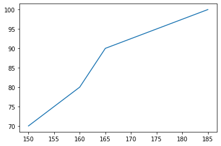

```python
# Make a simple plot
height = [150, 160, 165, 185]
weight = [70, 80, 90, 100]

# draw the plot
plt.plot(height, weight)
```

# Adding title, legends etc

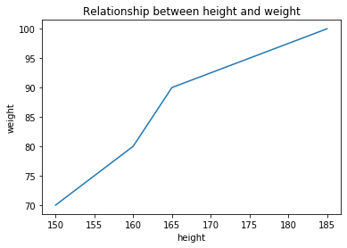

```python
# draw the plot
plt.plot(height, weight)

# add title
plt.title("Relationship between height and weight")

# add label x axis
plt.xlabel("height")

# add label y axis
plt.ylabel("weight")
```

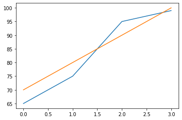

```python
# another variable
calories_burnt = [65, 75, 95, 99]

# draw the plot for calories burnt
plt.plot(calories_burnt)

# draw the plot for weight
plt.plot(weight)
```

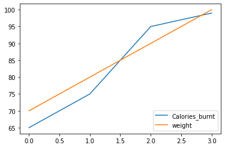

```python
# draw the plot for calories burnt
plt.plot(calories_burnt)
# draw the plot for weight
plt.plot(weight)

# add legend in the lower right part of the figure
plt.legend(labels = ['Calories_burnt', 'weight'], loc ='lower right')
```

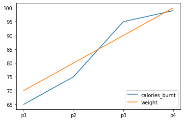

```python
# draw the plot
plt.plot(calories_burnt)
plt.plot(weight)

# add legend
plt.legend(labels = ['calories_burnt', 'weight'], loc = 'lower right')

# set labels for each of these persons
plt.xticks(ticks = [0, 1, 2, 3], labels = ['p1', 'p2', 'p3', 'p4']);
```